# Sampling for Posterior Inference

Matthew Talluto

25.11.2022

# Sampling the unknown

- Why *can’t* we just look at the conditional distributions?
- We have a mean and standard deviation

# Sampling the unknown

- Why *can’t* we just look at the conditional distributions?
- We have a mean and standard deviation

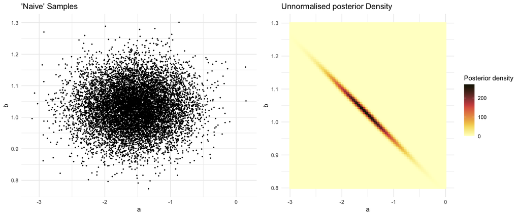

```r
naive_sample = data.frame(a = rnorm(1e4, fit$par[1], sds[1]),
                        b = rnorm(1e4, fit$par[2], sds[2]))
naive_plot = ggplot(naive_sample, aes(x=a, y=b)) + geom_point(size = 0.4) +
  theme_minimal() + ggtitle("'Naive' Samples")
```

# Sampling the unknown

- This technique of sampling to learn about something is quite useful
  - Here we have learned that we can’t ignore covariance among our parameters!
  - We must find a way to sample from a **joint** posterior distribution

[figure not shown]